# Credit Card Fraud Detection Using Machine Learning

Arpan Samanta

# Dataset

Here we have worked on a dataset given by Gabriel Preda. The dataset contains transactions made by credit cards in **september 2013** by European cardholders. The dataset contains transactions that occurres in 2 days. Out of these **2,84,807** transactions **492** fraud tarnsactions were successfully detected. The dataset contains the time difference (in minutes) for each transaction from the first transaction, the encrypted features of a transaction, the amount of transaction and the class of fraud prediction where 0 means **non-detected** and 1 implies **detected.**

The dataset is easily accessible at [Credit Card Fraud Detection](https://www.kaggle.com/datasets/mlg-ulb/creditcardfraud). we will first call the necessary libraries then the dataset we are going to work on.

# Objective

Our main objective is to predict whether a transaction is fraud or not by applying necessary algorithms to our **training dataset**. We will predict the model on **testing dataset**.

# Data Description

We need to first import the dataset. Then we’ll discuss about different feartures of the dataset as below. But, beforehand let us just call the necessary libraries and set the seed as we will use function that returns random outcomes, setting the seed will help us get same results.

```r
#Importing necessary libraries
library(ROSE)
library(smotefamily)
library(dplyr)
library(caTools)
library(pROC)
library(caret)

#Setting the seed
set.seed(123)
```

Let us now import the data set and work on it.

```r
#Importing Data.
#NOTE: To read the .csv file you must first download the data.csv file to your working directory
data=read.csv('data.csv')  #Importing the data.csv dataset

str(data)      #The different features and their datatypes in the dataset
```

```
## 'data.frame':    284807 obs. of  31 variables:
##  $ Time  : num  0 0 1 1 2 2 4 7 7 9 ...
##  $ V1    : num  -1.36 1.192 -1.358 -0.966 -1.158 ...
##  $ V2    : num  -0.0728 0.2662 -1.3402 -0.1852 0.8777 ...
##  $ V3    : num  2.536 0.166 1.773 1.793 1.549 ...
##  $ V4    : num  1.378 0.448 0.38 -0.863 0.403 ...
##  $ V5    : num  -0.3383 0.06 -0.5032 -0.0103 -0.4072 ...
##  $ V6    : num  0.4624 -0.0824 1.8005 1.2472 0.0959 ...
##  $ V7    : num  0.2396 -0.0788 0.7915 0.2376 0.5929 ...
##  $ V8    : num  0.0987 0.0851 0.2477 0.3774 -0.2705 ...
##  $ V9    : num  0.364 -0.255 -1.515 -1.387 0.818 ...
##  $ V10   : num  0.0908 -0.167 0.2076 -0.055 0.7531 ...
##  $ V11   : num  -0.552 1.613 0.625 -0.226 -0.823 ...
##  $ V12   : num  -0.6178 1.0652 0.0661 0.1782 0.5382 ...
##  $ V13   : num  -0.991 0.489 0.717 0.508 1.346 ...
```

[output cut: 17 more lines]

**Comment:** The key features contain Time, Amount and the 28 unknown features of the credit cards which are numeric in nature. Also it has the Class (of fraud detection) which is boolean in nature.

# Exploratory Data Analysis (EDA)

First we need to check whether there exists any missing data in the dataset.

```r
#Checking For Missing Data
sum(is.na(data))
```

```
## [1] 0
```

**Comment:** There is no missing data in the data set.

Now we’ll check the summary of the dataset such as mean, median, qartiles, variance etc of the different parameters. Note that, we will omit the ‘Time’ parameter as it is a identification variable and of no use to us.

```r
#Removing the time column since it is of no use for us
data=data[,-1]

#Summary of the dataset
summary(data)
```

```
##        V1                  V2                  V3                 V4
##  Min.   :-56.40751   Min.   :-72.71573   Min.   :-48.3256   Min.   :-5.68317
##  1st Qu.: -0.92037   1st Qu.: -0.59855   1st Qu.: -0.8904   1st Qu.:-0.84864
##  Median :  0.01811   Median :  0.06549   Median :  0.1799   Median :-0.01985
##  Mean   :  0.00000   Mean   :  0.00000   Mean   :  0.0000   Mean   : 0.00000
##  3rd Qu.:  1.31564   3rd Qu.:  0.80372   3rd Qu.:  1.0272   3rd Qu.: 0.74334
##  Max.   :  2.45493   Max.   : 22.05773   Max.   :  9.3826   Max.   :16.87534
##        V5                   V6                 V7                 V8
##  Min.   :-113.74331   Min.   :-26.1605   Min.   :-43.5572   Min.   :-73.21672
##  1st Qu.:  -0.69160   1st Qu.: -0.7683   1st Qu.: -0.5541   1st Qu.: -0.20863
##  Median :  -0.05434   Median : -0.2742   Median :  0.0401   Median :  0.02236
##  Mean   :   0.00000   Mean   :  0.0000   Mean   :  0.0000   Mean   :  0.00000
##  3rd Qu.:   0.61193   3rd Qu.:  0.3986   3rd Qu.:  0.5704   3rd Qu.:  0.32735
##  Max.   :  34.80167   Max.   : 73.3016   Max.   :120.5895   Max.   : 20.00721
##        V9                 V10                 V11                V12
##  Min.   :-13.43407   Min.   :-24.58826   Min.   :-4.79747   Min.   :-18.6837
##  1st Qu.: -0.64310   1st Qu.: -0.53543   1st Qu.:-0.76249   1st Qu.: -0.4056
##  Median : -0.05143   Median : -0.09292   Median :-0.03276   Median :  0.1400
##  Mean   :  0.00000   Mean   :  0.00000   Mean   : 0.00000   Mean   :  0.0000
##  3rd Qu.:  0.59714   3rd Qu.:  0.45392   3rd Qu.: 0.73959   3rd Qu.:  0.6182
##  Max.   : 15.59500   Max.   : 23.74514   Max.   :12.01891   Max.   :  7.8484
##       V13                V14                V15                V16
##  Min.   :-5.79188   Min.   :-19.2143   Min.   :-4.49894   Min.   :-14.12985
##  1st Qu.:-0.64854   1st Qu.: -0.4256   1st Qu.:-0.58288   1st Qu.: -0.46804
##  Median :-0.01357   Median :  0.0506   Median : 0.04807   Median :  0.06641
##  Mean   : 0.00000   Mean   :  0.0000   Mean   : 0.00000   Mean   :  0.00000
##  3rd Qu.: 0.66251   3rd Qu.:  0.4931   3rd Qu.: 0.64882   3rd Qu.:  0.52330
##  Max.   : 7.12688   Max.   : 10.5268   Max.   : 8.87774   Max.   : 17.31511
##       V17                 V18                 V19
##  Min.   :-25.16280   Min.   :-9.498746   Min.   :-7.213527
##  1st Qu.: -0.48375   1st Qu.:-0.498850   1st Qu.:-0.456299
##  Median : -0.06568   Median :-0.003636   Median : 0.003735
##  Mean   :  0.00000   Mean   : 0.000000   Mean   : 0.000000
##  3rd Qu.:  0.39968   3rd Qu.: 0.500807   3rd Qu.: 0.458949
##  Max.   :  9.25353   Max.   : 5.041069   Max.   : 5.591971
##       V20                 V21                 V22
##  Min.   :-54.49772   Min.   :-34.83038   Min.   :-10.933144
##  1st Qu.: -0.21172   1st Qu.: -0.22839   1st Qu.: -0.542350
##  Median : -0.06248   Median : -0.02945   Median :  0.006782
##  Mean   :  0.00000   Mean   :  0.00000   Mean   :  0.000000
##  3rd Qu.:  0.13304   3rd Qu.:  0.18638   3rd Qu.:  0.528554
##  Max.   : 39.42090   Max.   : 27.20284   Max.   : 10.503090
##       V23                 V24                V25                 V26
##  Min.   :-44.80774   Min.   :-2.83663   Min.   :-10.29540   Min.   :-2.60455
##  1st Qu.: -0.16185   1st Qu.:-0.35459   1st Qu.: -0.31715   1st Qu.:-0.32698
##  Median : -0.01119   Median : 0.04098   Median :  0.01659   Median :-0.05214
##  Mean   :  0.00000   Mean   : 0.00000   Mean   :  0.00000   Mean   : 0.00000
##  3rd Qu.:  0.14764   3rd Qu.: 0.43953   3rd Qu.:  0.35072   3rd Qu.: 0.24095
##  Max.   : 22.52841   Max.   : 4.58455   Max.   :  7.51959   Max.   : 3.51735
##       V27                  V28                Amount             Class
##  Min.   :-22.565679   Min.   :-15.43008   Min.   :    0.00   Min.   :0.000000
##  1st Qu.: -0.070840   1st Qu.: -0.05296   1st Qu.:    5.60   1st Qu.:0.000000
##  Median :  0.001342   Median :  0.01124   Median :   22.00   Median :0.000000
##  Mean   :  0.000000   Mean   :  0.00000   Mean   :   88.35   Mean   :0.001728
##  3rd Qu.:  0.091045   3rd Qu.:  0.07828   3rd Qu.:   77.17   3rd Qu.:0.000000
##  Max.   : 31.612198   Max.   : 33.84781   Max.   :25691.16   Max.   :1.000000
```

```r
#Variance of the parameters
Column_Varience <- as.data.frame(sapply(data, function(x) var = var(x)))
Column_Varience
```

```
##        sapply(data, function(x) var = var(x))
## V1                               3.836489e+00
## V2                               2.726820e+00
## V3                               2.299029e+00
## V4                               2.004684e+00
## V5                               1.905081e+00
## V6                               1.774946e+00
## V7                               1.530401e+00
## V8                               1.426479e+00
## V9                               1.206992e+00
## V10                              1.185594e+00
## V11                              1.041855e+00
## V12                              9.984034e-01
## V13                              9.905708e-01
## V14                              9.189055e-01
## V15                              8.378034e-01
## V16                              7.678191e-01
## V17                              7.213734e-01
## V18                              7.025394e-01
## V19                              6.626619e-01
## V20                              5.943254e-01
## V21                              5.395255e-01
## V22                              5.266428e-01
## V23                              3.899507e-01
## V24                              3.668084e-01
## V25                              2.717308e-01
## V26                              2.325429e-01
## V27                              1.629192e-01
## V28                              1.089550e-01
## Amount                           6.256007e+04
## Class                            1.724507e-03
```

## Data Visualization

### Understanding how different parameters are affecting the `Class`

The scattered `plot()`s for the `Class` and the different parameters are given below. The fitted regression lines are also there with `col = 'red'`.

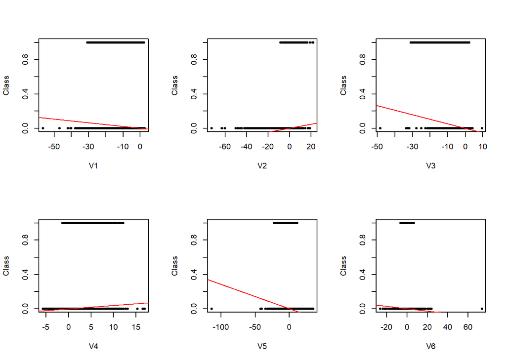

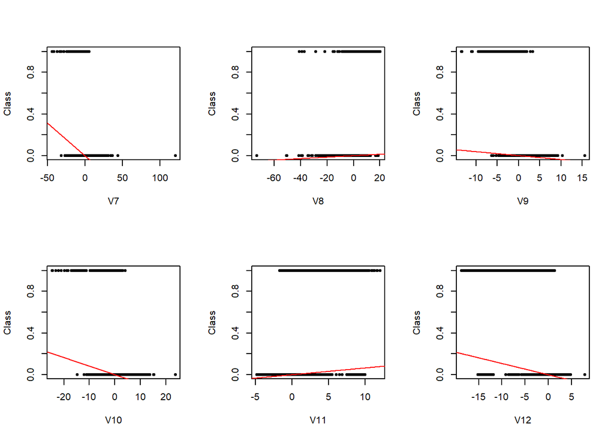

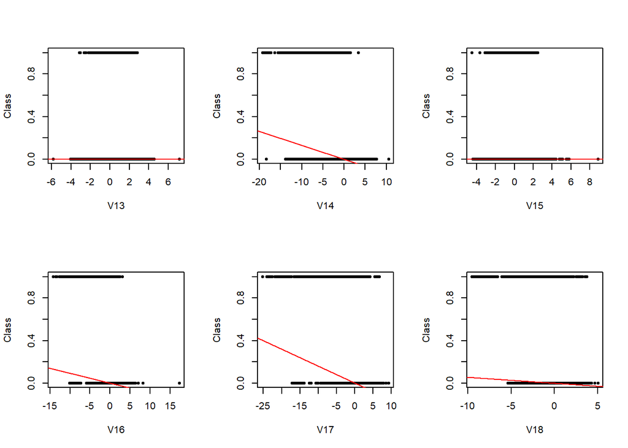

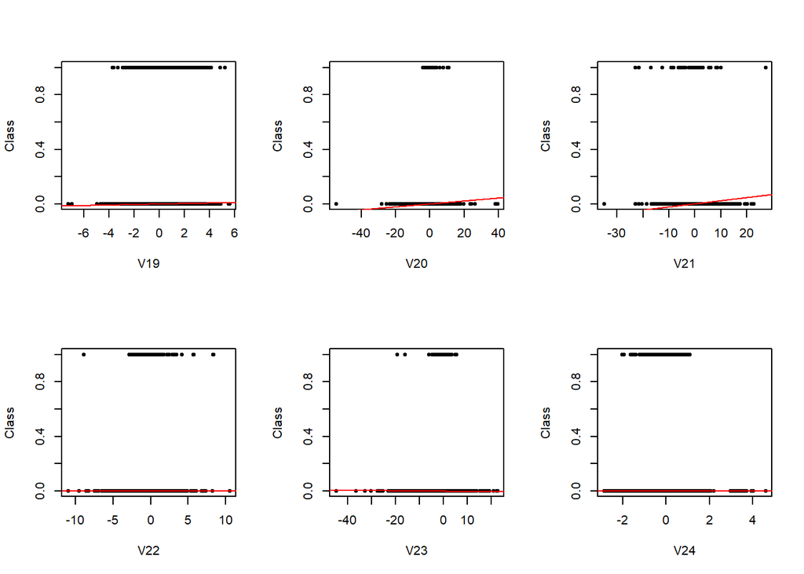

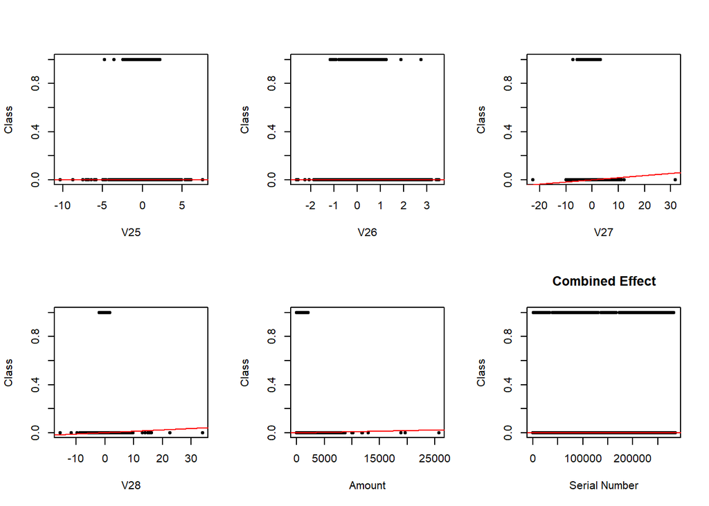

**Comment:** Here I’ve shown the graph of changing `Class` and parameters along with their fitted regression. Also, the last `plot` is showing the combined fitted regression of all the parameters on `Class`. Though, fitted regression lines (coloured in `red`) are mostly expanding towards densedly dotted area, but the linear regression doesn’t properly estimates the categorical data, `Class` as it is not a numerical variable, it has boolean nature. We’ll proceed with a more sweetable model in the next sections.

### Visualising `Class` by `barplot()`

The frequency distribution as well as the `barplot()` of the `Class` of fraud detection is given below.

```r
#Frequency Distribution of Fraud Detection
table(data$Class)
```

```
##
##      0      1
## 284315    492
```

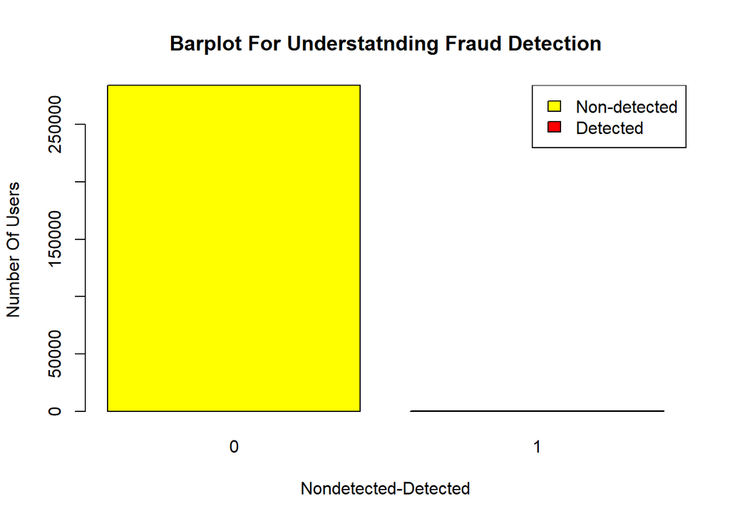

**Comment:** There are 284315 cases of non-detecting fraud, the fraud detected cases (492) are so small compared to that, that, it is not even properly represented in the `barplot()`. From the clear notion of the `plot()`, we see that this is a heavily imbalanced data. We need to balance the data via data augmentation.

## Applying SMOTE

SMOTE, or Synthetic Minority Over-sampling Technique, is a method used to address class imbalance in classification problems. Instead of simply duplicating samples from the minority class, it generates synthetic examples. It does this by selecting a minority class sample, finding its nearest neighbors, and creating a new synthetic point along the line between the sample and one of its neighbors. This helps increase the representation of the minority class in a more generalized way, reducing the risk of overfitting that comes with random oversampling. However, SMOTE may sometimes introduce noise if the classes overlap too much.

```r
smote_out <- SMOTE(X = data[,-30], target = data$Class, K = 5, dup_size = 30)   #Applying SMOTE method
data1 <- as.data.frame(smote_out$data)     #This over sampled data is our new data that we will be working with
head(data1)
```

```
##          V1        V2        V3        V4         V5         V6         V7
## 1 -2.006582 3.6765774 -5.463811 7.2320583 -1.6278595 -0.9967546 -4.2998326
## 2  1.878230 1.3256296 -2.333469 4.2331512  1.3551840 -0.8535082  0.7160251
## 3 -5.753852 0.5776098 -6.312782 5.1594014 -1.6983199 -2.6832864 -7.9343891
## 4 -1.783229 3.4027937 -3.822742 2.6253682 -1.9764154 -2.7316890 -3.4305591
## 5 -0.443794 1.2713953  1.206178 0.7903712  0.4189353 -0.8483757  0.9176906
## 6  1.261324 2.7268003 -5.435019 5.3427590  1.4470430 -1.4425841 -0.8987019
##           V8         V9        V10       V11        V12        V13       V14
## 1  2.2688668 -3.6510670 -4.4009298 4.2132129 -5.7378152 -0.8756934 -8.893726
## 2 -0.1649098 -1.5023445  0.2594111 1.4512375 -0.2805233 -0.7567941 -2.757557
## 3  2.3735499 -3.0730789 -7.1451366 6.2500676 -9.1508227 -1.3761415 -9.982585
## 4  1.4132035 -0.7769415 -6.1998818 4.3667135 -8.2432624  0.3457612 -6.590550
## 5 -0.2355114 -0.2856921 -0.8678997 0.6149771 -0.6579477 -0.9484120 -1.635145
## 6  0.1230620 -2.7484959 -3.2024361 1.9913606 -3.9864162  0.5772068 -8.485795
##          V15         V16        V17        V18        V19         V20
```

[output cut: 20 more lines]

Let us now check the frequency distribution and `barplot()` of the augmented new data.

```r
#Frequency table for the Class of new balanced data
table(data1$class)
```

```
##
##      0      1
## 284315  15252
```

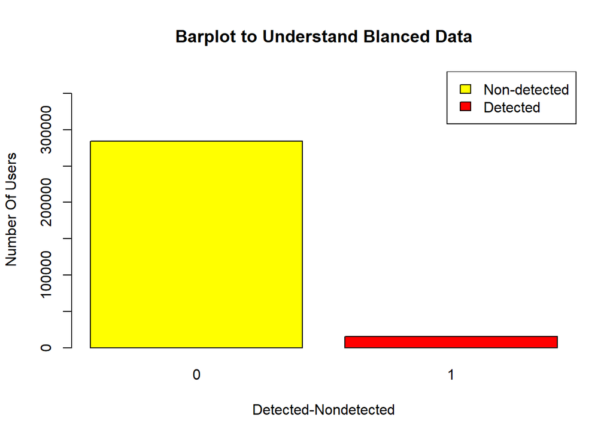

## Data Manupulation

We will here basically do feature scaling of the data. Since large amounts were transferred, so normalization of the data will help us to compare the different predictors.

```r
data1[,-30] <- data1[,-30] %>%
  scale()
head(data1)      #Checking the first 6 lines of the edited data
```

```
##            V1        V2         V3        V4         V5         V6         V7
## 1 -0.68104528 1.7403075 -1.9586237 3.9120034 -0.7770973 -0.6700931 -1.7644873
## 2  0.80575228 0.5704298 -0.7615964 2.2388268  0.7975595 -0.5667155  0.4300010
## 3 -2.11520282 0.1982005 -2.2832659 2.7556084 -0.8142911 -1.8872248 -3.3546424
## 4 -0.59556351 1.6040673 -1.3310871 1.3417983 -0.9610892 -1.9221559 -1.3841714
## 5 -0.08293417 0.5434418  0.5919472 0.3180007  0.3033427 -0.5630115  0.5182317
## 6  0.56964971 1.2676798 -1.9476138 2.8579089  0.8460491 -0.9918381 -0.2764583
##            V8        V9        V10       V11         V12        V13        V14
## 1  1.20556522 -2.681281 -2.1449483 2.8605273 -2.80862711 -0.8744297 -4.2910247
## 2 -0.10744836 -1.046189  0.2800782 0.8980415  0.01321426 -0.7547809 -1.2107346
## 3  1.26204141 -2.241455 -3.5729069 4.3077880 -4.57341559 -1.3780325 -4.8376197
## 4  0.74393802 -0.494187 -3.0810399 2.9695951 -4.10413685  0.3547247 -3.1348555
## 5 -0.14553767 -0.120366 -0.3065224 0.3038475 -0.18194331 -0.9476068 -0.6472959
## 6  0.04791136 -1.994460 -1.5213074 1.2818190 -1.90301860  0.5876293 -4.0862474
##          V15        V16        V17          V18        V19          V20
```

[output cut: 20 more lines]

# Splitting the Dataset

According to our objective, we are interested in splitting the dataset into training data set and testing data set.

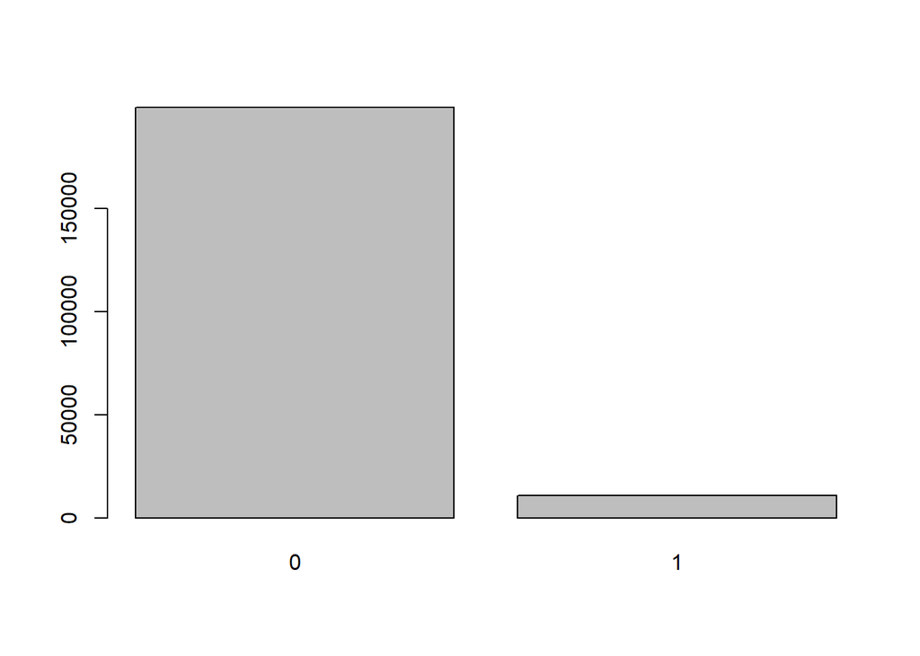

```r
#We will not be splitting the data set in a particular way.It will be random. So we set the seed to get same results.
set.seed(123456789)    #Setting the seed

split=sample.split(data1$class,SplitRatio=0.7)     #Including the data into splitting sets randomly
training_set=subset(data1,split==TRUE)
testing_set=subset(data1,split==FALSE)
barplot(table(training_set$class))
```

```r
head(training_set)
```

```
##            V1        V2         V3       V4         V5         V6        V7
## 1  -0.6810453 1.7403075 -1.9586237 3.912003 -0.7770973 -0.6700931 -1.764487
## 2   0.8057523 0.5704298 -0.7615964 2.238827  0.7975595 -0.5667155  0.430001
## 3  -2.1152028 0.1982005 -2.2832659 2.755608 -0.8142911 -1.8872248 -3.354642
## 7  -3.9823141 3.5194760 -6.6304443 4.454358 -5.2844306 -3.2057706 -5.562851
## 9  -2.2805403 3.4453549 -4.8520714 4.346499 -4.0801744 -2.8191004 -5.233844
## 10 -4.9621922 6.2733199 -3.6575436 1.729541 -2.4521933  4.2061454 -8.086970
##             V8         V9        V10       V11         V12         V13
## 1    1.2055652 -2.6812806 -2.1449483 2.8605273 -2.80862711 -0.87442969
## 2   -0.1074484 -1.0461894  0.2800782 0.8980415  0.01321426 -0.75478087
## 3    1.2620414 -2.2414549 -3.5729069 4.3077880 -4.57341559 -1.37803253
## 7    3.6412413 -3.4485277 -7.6210094 5.8276798 -8.35567070  0.34743481
## 9    2.6634813 -3.1357561 -6.6015458 6.0402481 -8.72662940  0.07679941
## 10 -20.1705263 -0.2009118 -2.4839966 2.9980820 -2.22585073 -1.91474115
##          V14        V15       V16       V17        V18       V19          V20
```

[output cut: 20 more lines]

**Comment:** The `SplitRatio = 0.7` means that we are deviding the whole dataset in a 70-30 percentage where 70% of the data will go to the `training_set` and the remaining 30% will go to the `testing_set`.

# Model Building

**Logistic model** (or logit model) is a statistical model that models the log-odds of an event as a linear combination of one or more independent variables. It is used in various fields roughly saying machine learning, medical sectors, social science etc. In general practice it takes a categorical variable as a response and numeric variable(s) as predictor(s). We are choosing logit model for our project. Firstly, we’ll try to fit a proper logit model on the `training_set` and predict the **probability of predicting fraud**. Then we’ll check for sweetable cutpoints by which we’ll predict the `Class` of fraud detection.

```r
training_set$class <- as.factor(training_set$class)
#Fitting logistic model on training_set
logit_model=glm(class~.,data= training_set, family = binomial(link = 'logit'))
summary(logit_model)
```

```
##
## Call:
## glm(formula = class ~ ., family = binomial(link = "logit"), data = training_set)
##
## Coefficients:
##              Estimate Std. Error  z value Pr(>|z|)
## (Intercept) -5.200264   0.045331 -114.717  < 2e-16 ***
## V1           0.513198   0.049945   10.275  < 2e-16 ***
## V2          -0.014081   0.069974   -0.201 0.840518
## V3           0.282786   0.052708    5.365 8.09e-08 ***
## V4           1.498747   0.045857   32.683  < 2e-16 ***
## V5           0.202877   0.056426    3.595 0.000324 ***
## V6          -0.255931   0.043409   -5.896 3.73e-09 ***
## V7          -0.264300   0.081679   -3.236 0.001213 **
## V8          -0.571866   0.031230  -18.311  < 2e-16 ***
## V9          -0.324056   0.052020   -6.229 4.68e-10 ***
## V10         -1.313259   0.083946  -15.644  < 2e-16 ***
## V11          0.462371   0.037258   12.410  < 2e-16 ***
## V12         -1.118929   0.054993  -20.347  < 2e-16 ***
## V13         -0.319074   0.026628  -11.983  < 2e-16 ***
## V14         -1.564455   0.049983  -31.300  < 2e-16 ***
## V15         -0.066424   0.026992   -2.461 0.013859 *
## V16         -0.326190   0.064306   -5.072 3.93e-07 ***
## V17         -0.307766   0.058815   -5.233 1.67e-07 ***
## V18         -0.226239   0.049445   -4.576 4.75e-06 ***
## V19         -0.009725   0.030270   -0.321 0.748005
## V20         -0.210731   0.039101   -5.389 7.07e-08 ***
## V21          0.271455   0.026811   10.125  < 2e-16 ***
## V22          0.282827   0.035045    8.071 7.00e-16 ***
## V23         -0.052758   0.022145   -2.382 0.017204 *
## V24          0.008122   0.032959    0.246 0.805346
## V25          0.055927   0.027975    1.999 0.045594 *
## V26         -0.127424   0.034731   -3.669 0.000244 ***
## V27         -0.169051   0.037999   -4.449 8.63e-06 ***
## V28         -0.029311   0.017238   -1.700 0.089070 .
## Amount       0.206497   0.077913    2.650 0.008041 **
## ---
## Signif. codes:  0 '***' 0.001 '**' 0.01 '*' 0.05 '.' 0.1 ' ' 1
##
## (Dispersion parameter for binomial family taken to be 1)
##
##     Null deviance: 84378  on 209695  degrees of freedom
## Residual deviance: 13535  on 209666  degrees of freedom
## AIC: 13595
##
## Number of Fisher Scoring iterations: 11
```

**Note:** In the `Pr(>|z|)` column we’re basically given the p-values for the corresponding variables. We can observe for smaller p-value a variable is marked as `*` , `**` or `***`, they’re denoting the significance of a predictor. Greater the star more significant the predictor is.

Let us now predict the probability of fraud detection by fitting the `logit_model` on the `training_set`.

```r
#Predicting the probability of fraud detection
predict_class=predict(logit_model,type = 'response',newdata = training_set[,-30])    #We're deleting the last column in order to choose only the predictors
pred=as.vector(predict_class)
Class_vs_probability <- data.frame(training_set[,30],pred)
colnames(Class_vs_probability) <- c('Class','Probability')
head(Class_vs_probability)
```

```
##   Class Probability
## 1     1   0.9999998
## 2     1   0.5311535
## 3     1   1.0000000
## 4     1   1.0000000
## 5     1   1.0000000
## 6     1   1.0000000
```

**Comment:** Even though we got our necessary `Probability`, they are not categorical in nature. Note that, `Probability` always lies between 0 and 1. So, we can choose a sweetable cut point below which they’re considered as 0 else 1. Thus we can get our predicted `Class` which is categorical in nature.

## Choosing the cut point

We will try to find the cut points using different approaches.

### Youden’s J statistic

Youden’s J statistic (also called Youden’s index) is a single statistic that captures the performance of a dichotomous diagnostic test. It is given as following ;
$$J = sensivity + specificity -1$$

```r
# Generate ROC object
roc_obj <- roc(training_set$class , pred)
# Calculate the optimal cutoff using Youden's J statistic
optimal_cutoff <- coords(roc_obj, "best", ret = "threshold", best.method = "youden")
optimal_cutoff=optimal_cutoff$threshold

# Print the optimal cutoff
print(optimal_cutoff)
```

```
## [1] 0.04532174
```

```r
# Classify probabilities into 0 or 1 using the optimal cutoff
predicted_classes_optimal <- ifelse(pred > optimal_cutoff, 1, 0)

# Print the first few predicted classes using the optimal cutoff
predict_df1 <- data.frame(training_set[,30],predicted_classes_optimal)
colnames(predict_df1) <- c('Actual Class','Predicted Class')
head(predict_df1)
```

```
##   Actual Class Predicted Class
## 1            1               1
## 2            1               1
## 3            1               1
## 4            1               1
## 5            1               1
## 6            1               1
```

The frequency table as well as the bar plot for the `predicted_classes_optimal` i.e. the predicted `Class` is given below.

```r
#Frequency Distribution of Predicted Fraud Detection
table(predicted_classes_optimal)
```

```
## predicted_classes_optimal
##      0      1
## 196118  13578
```

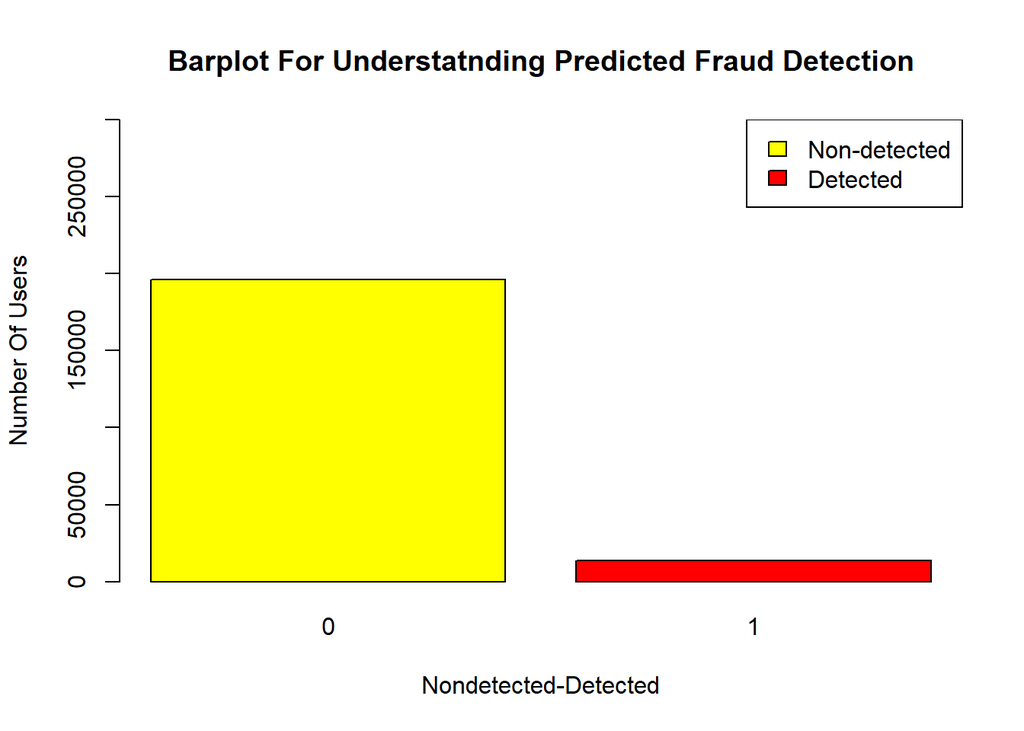

### Using general 0.5 as cut off

Instead of any method we are using `cut point = 0.5`, since it is the midpoint of (0,1).

```r
# Classify probabilities into 0 or 1 using cutoff = 0.5
predicted_classes_optimal2 <- ifelse(pred > 0.5, 1, 0)

# Print the first few predicted classes using the optimal cutoff
predict_df2 <- data.frame(training_set[,30],predicted_classes_optimal2)
colnames(predict_df2) <- c('Actual Class','Predicted Class')
head(predict_df2)
```

```
##   Actual Class Predicted Class
## 1            1               1
## 2            1               1
## 3            1               1
## 4            1               1
## 5            1               1
## 6            1               1
```

Again, frequency table as well as the bar plot for the `predicted_classes_optima2` i.e. the predicted `Class` using `cut point = 0.5` is given below.

```r
#Frequency Distribution of Predicted Fraud Detection
table(predicted_classes_optimal2)
```

```
## predicted_classes_optimal2
##      0      1
## 200184   9512
```

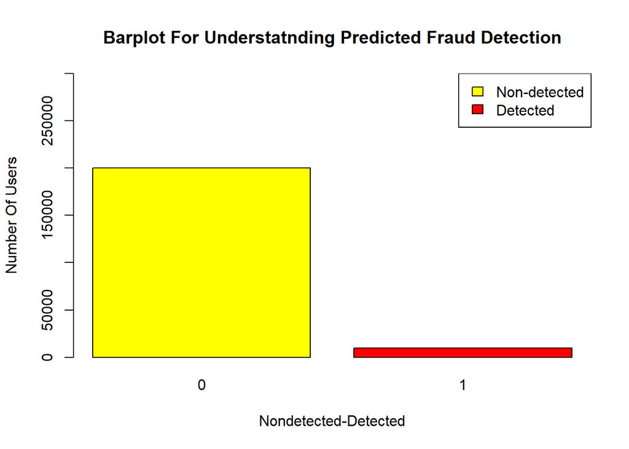

### selection of the proper cut point

We’re expressing ME in terms of percentage for simplicity.

**ME for J index**

```r
Accuracy=sum(predict_df1[,1]==predict_df1[,2])/length(predict_df1[,2])
Accuracy*100
```

```
## [1] 97.93129
```

**ME for `cut point == 0.5`**

```r
Accuracy2=sum(predict_df2[,1]==predict_df2[,2])/length(predict_df2[,2])
Accuracy2*100
```

```
## [1] 99.28849
```

## Goodness of Fit

We alredy found out that **ME** for this model is coming out to be

```r
ACCURACY= sum(predict_df1[,1]==predict_df1[,2])/length(predict_df1[,2])
ACCURACY*100
```

```
## [1] 97.93129
```

Let us check the area under ROC curve i.e. **AUC**. For that we need to first plot the ROC curve.

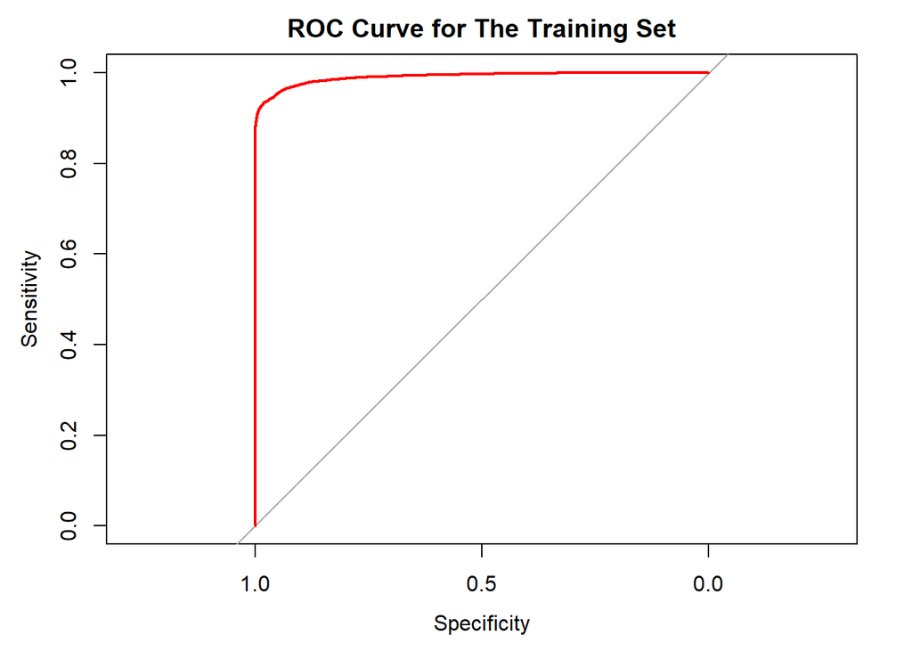

```
##
## Call:
## roc.default(response = training_set$class, predictor = pred)
##
## Data: pred in 199020 controls (training_set$class 0) < 10676 cases (training_set$class 1).
## Area under the curve: 0.9906
```

The area under ROC curve is now calculated:

```r
auc.model1 <- auc(roc_plot);auc.model1
```

```
## Area under the curve: 0.9906
```

Also, let us see the confusion matrix too,

```r
conf.matrix <- confusionMatrix(as.factor(predict_df1[,2]),as.factor(predict_df1[,1]))
conf.matrix
```

```
## Confusion Matrix and Statistics
##
##           Reference
## Prediction      0      1
##          0 195400    718
##          1   3620   9958
##
##                Accuracy : 0.9793
##                  95% CI : (0.9787, 0.9799)
##     No Information Rate : 0.9491
##     P-Value [Acc > NIR] : < 2.2e-16
##
##                   Kappa : 0.8103
##
##  Mcnemar's Test P-Value : < 2.2e-16
##
##             Sensitivity : 0.9818
##             Specificity : 0.9327
##          Pos Pred Value : 0.9963
##          Neg Pred Value : 0.7334
##              Prevalence : 0.9491
##          Detection Rate : 0.9318
##    Detection Prevalence : 0.9352
##       Balanced Accuracy : 0.9573
##
##        'Positive' Class : 0
##
```

```r
#RMSE
RMSE(predict_df1[,2],predict_df1[,1])*100
```

```
## [1] NA
```

# Fitting the model in `testing_set`

## Prediction of testing `class`

First let us predict the probabilities of fraud detection

```r
pred.test.prob <- predict(logit_model,type = 'response',newdata = testing_set[,-30])    #We're deleting the last column in order to choose only the predictors
test.data <- data.frame(testing_set$class, pred.test.prob)
colnames(test.data) <- c('Actual Class', 'Probability')
head(test.data)
```

```
##    Actual Class Probability
## 4             1  0.99999457
## 5             1  0.07883896
## 6             1  0.99997856
## 8             1  1.00000000
## 12            1  0.99579252
## 19            1  0.05103437
```

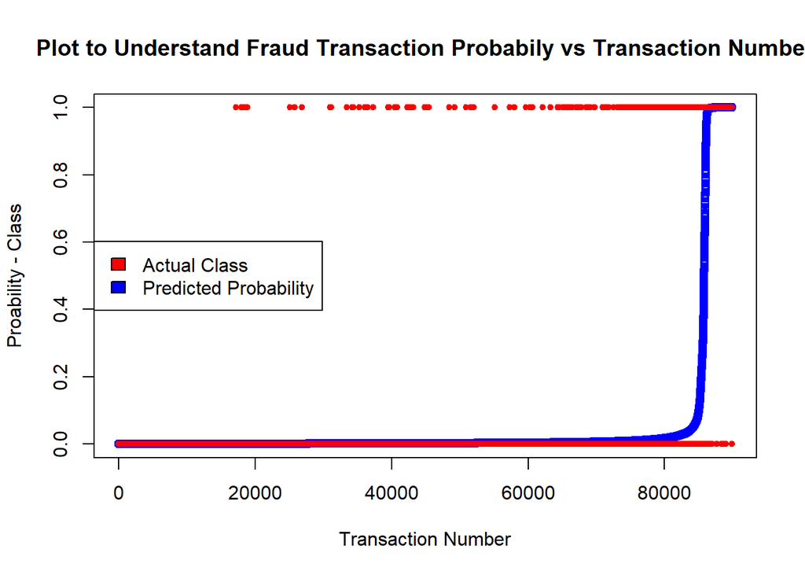

```r
pred.test.class <- ifelse(pred.test.prob > optimal_cutoff, 1, 0)
test.data.class <- data.frame(testing_set$class, pred.test.prob,pred.test.class)
colnames(test.data.class) <- c('Actual Class', 'Probability','Predicted Class')
head(test.data.class)
```

```
##    Actual Class Probability Predicted Class
## 4             1  0.99999457               1
## 5             1  0.07883896               1
## 6             1  0.99997856               1
## 8             1  1.00000000               1
## 12            1  0.99579252               1
## 19            1  0.05103437               1
```

**The Frequency Table and Barplot for the Predicted Class in `testing_set` is Given Below**

```r
#Frequency table
table(pred.test.class)
```

```
## pred.test.class
##     0     1
## 84014  5857
```

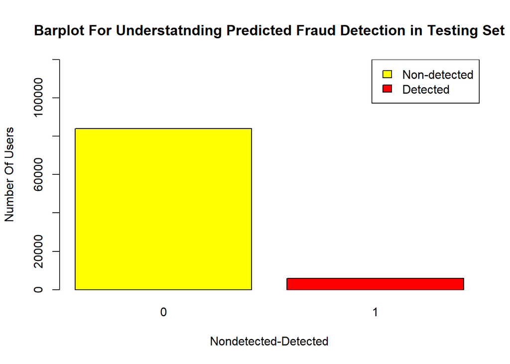

**Comment** The `plot()` shows more or less similar results like the original data. But we need to check the goodness of fit for a more acccurate verification.

## Confusion Matrix

In the field of machine learning and specifically the problem of statistical classification, a confusion matrix, also known as error matrix,[1] is a specific table layout that allows visualization of the performance of an algorithm, typically a supervised learning one.

For a binary categorical variable, a confusion matrix has 4 inputs, True Negative, True Positive, False Positive and False Negative. We will discuss those in our confusion matrix.

```r
library(caret)
conf.matrix <- confusionMatrix(as.factor(test.data.class[,3]),as.factor(test.data.class[,1]))
conf.matrix
```

```
## Confusion Matrix and Statistics
##
##           Reference
## Prediction     0     1
##          0 83725   289
##          1  1570  4287
##
##                Accuracy : 0.9793
##                  95% CI : (0.9784, 0.9802)
##     No Information Rate : 0.9491
##     P-Value [Acc > NIR] : < 2.2e-16
##
##                   Kappa : 0.811
##
##  Mcnemar's Test P-Value : < 2.2e-16
##
##             Sensitivity : 0.9816
##             Specificity : 0.9368
##          Pos Pred Value : 0.9966
##          Neg Pred Value : 0.7319
##              Prevalence : 0.9491
##          Detection Rate : 0.9316
##    Detection Prevalence : 0.9348
##       Balanced Accuracy : 0.9592
##
##        'Positive' Class : 0
##
```

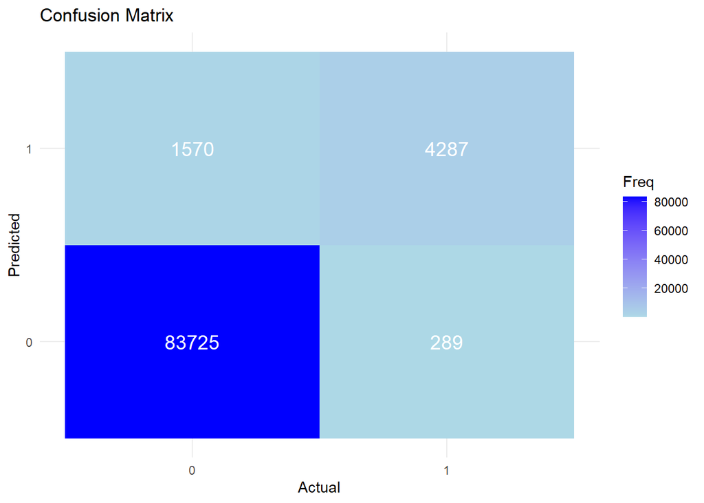

## Goodness of Fit

The different accuracy measure are given below

```r
#Missclassification Error
Accuracy_test=((sum(test.data.class[,1]==test.data.class[,3])/length(test.data.class[,1])))*100
Accuracy_test
```

```
## [1] 97.93148
```

**ROC CURVE**

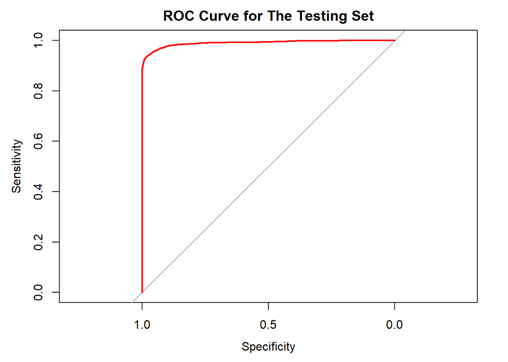

```r
#ROC curve
roc_obj_test=roc(test.data.class[,1],test.data.class[,2])
plot(roc_obj_test,main='ROC Curve for The Testing Set',col='red')
```

The area under the curve is given by

```r
auc(roc_obj_test)
```

```
## Area under the curve: 0.9901
```

**Interpretation** All the measures are showing similar results as the training set data. Although it may look like a case of over fitting due to high accuracy in `Confusion Matrix`. The model is moderate.

From the confusion matrix we can calculate the type 1 and 2 error

```r
#Confusion Matrix
conf_mt <- as.matrix(conf_tabl)

#Type 1 error
type1 <- conf_mt[2,1]/(conf_mt[2,1]+conf_mt[1,1]);type1
```

```
## [1] 0.01840671
```

```r
#Type 2 error
type2 <- conf_mt[1,2]/(conf_mt[1,2] + conf_mt[2,2]);type2
```

```
## [1] 0.06315559
```

**Interpretation** In general we know type 1 error is more important than type 2. But if you interprete the type 2 error here, it gives the proportion of transactions which are predicted as not being fraud although they’re fraud in actual scenario. For industrial purpose this number is more important to us. The type 2 error is coming out to be small. So, our model extracts a good result.